# A guide for importing and analysing ruminal pH bolus data

## Introduction

This package implements a simplified and automated version of the models discussed by Denwood et al (2018):

Denwood, M.J., J.L. Kleen, D.B. Jensen, and N.N. Jonsson. 2018. Describing temporal variation in reticuloruminal pH using continuous monitoring data. J. Dairy Sci. 101:233-245. doi:10.3168/jds.2017-12828

http://doi.org/10.3168/jds.2017-12828

For more information, contact the corresponding author.

## Installation

Install the required packages from CRAN, as well as the BoluspH data from GitHub (this only needs to be done once, unless the package is updated):

```r
install.packages(c('tidyverse','mgcv','devtools','knitr'))
devtools::install_github('boydorr/BoluspH', build_vignettes=TRUE)
```

You should then be able to access this vignette from within R using:

```r
vignette('BoluspH', package='BoluspH')
```

## Basic Example

Let's say we have 3 files to import - one SmaXtec file, one WellCow file and one in a custom format. First we need to set up a data frame with (at a minimum) the ID numbers to be used plus the filenames relating to these individuals:

```r
meta <- data.frame(ID=c('Cow_1','Cow_2','Cow_3'), Filename=c('ST1.xlsx','WC1.csv','CS1.csv'), stringsAsFactors=FALSE)
```

This could optionally also include milking times, start and end dates for the data to be used, and other information e.g. Farm that will be merged with the outputs, e.g.:

```r
meta <- data.frame(ID=c('Cow_1','Cow_2','Cow_3'), Filename=c('ST1.xlsx','WC1.csv','CS1.csv'), Milking=c('09:00,16:00', '07:00,13:00,18:00', ''), Farm=c('FarmA','FarmB','FarmC'), stringsAsFactors=FALSE)
```

We then need to set up a model container using this meta-data:

```r
library('BoluspH')
model <- BoluspH(meta)
```

```
## Successfully set up a model container for 3 individuals
```

Then we can add the data by telling the model the working directory in which it can be found (in this case within the package itself for demonstration purposes). First we can add SmaXtec data (these are the only ones with .xlsx extension), and then WellCow data for individual 'Cow_2', and then finally the rest of the data in a custom data format:

```r
testdir <- system.file("extdata", package="BoluspH")
model$AddSmaXtecData(testdir)
```

```
## Importing  1  files...
##  Reading:  /private/var/folders/20/0xsn54bj2jbbzm0yn28zd_0h0000gr/T/RtmpNOdAI7/Rinst13414bc186a6/BoluspH/extdata/ST1.xlsx
##  Done
```

```r
model$AddWellCowData(testdir, ID='Cow_2')
```

```
## Importing  1  files...
##  Reading:  /private/var/folders/20/0xsn54bj2jbbzm0yn28zd_0h0000gr/T/RtmpNOdAI7/Rinst13414bc186a6/BoluspH/extdata/WC1.csv
##  Done
```

```r
model$AddCustomData(testdir, skip=13, date_col=3, time_col=4, pH_col=6, csv=TRUE, sep=';', dec=',', date_format='%d.%m.%Y', time_format='%H:%M')
```

```
## Importing  1  files...
##  Reading:  /private/var/folders/20/0xsn54bj2jbbzm0yn28zd_0h0000gr/T/RtmpNOdAI7/Rinst13414bc186a6/BoluspH/extdata/CS1.csv
##  Done
```

It is also possible to add data from different paths using multiple calls to the methods above, and/or add data in different formats using the AddCustomData method.

Once all data has been imported we run the models, optionally including the GAM (long-term trend) and milking-related sine wave terms ('none', 'fixed' or 'adjusted'):

```r
model$RunModels(gam=TRUE, milking='adjusted')
```

```
## Running analyses for 3 individuals...
##
```

Notice that Cow_1 was automatically skipped due to insufficient data (this can be changed by adjusting the exclude_pre, exclude_post, and min_days arguments to the RunModels method).

Then extract and look at the overview information:

```r
overview_out <- model$GetOverview()
overview_out
```

```
##      ID      Start        End Filename      MilkingTimes  Farm
## 1 Cow_2 2015-06-05 2015-07-13  WC1.csv 07:00,13:00,18:00 FarmB
## 2 Cow_3 2019-11-12 2019-12-20  CS1.csv                   FarmC
##   MilkingFrequency intercept  edf_gam       sin_day     cos_day
## 1                3  6.473467 8.644300 -0.0007627788 -0.04387434
## 2                0  6.387348 8.983464  0.0484193594 -0.08565427
##   sin_milking cos_milking
## 1 0.001814161  0.01103238
## 2          NA          NA
```

And then extract the full observation-level data including predictions and residuals:

```r
data_out <- model$ExtractData()
str(data_out)
```

```
## 'data.frame':    10225 obs. of  6 variables:
##  $ ID        : chr  "Cow_1" "Cow_1" "Cow_1" "Cow_1" ...
##  $ Date      : Date, format: "2018-07-31" "2018-07-31" ...
##  $ Time      : POSIXct, format: "2018-07-31 00:02:00" "2018-07-31 00:12:00" ...
##  $ pH        : num  6.27 6.31 6.33 6.35 6.35 6.36 6.36 6.38 6.38 6.38 ...
##  $ prediction: num  NA NA NA NA NA NA NA NA NA NA ...
##  $ residual  : num  NA NA NA NA NA NA NA NA NA NA ...
```

```r
summary(data_out)
```

```
##       ID                 Date                 Time
##  Length:10225       Min.   :2015-06-05   Min.   :2015-06-05 00:10:50
##  Class :character   1st Qu.:2015-07-01   1st Qu.:2015-07-01 15:10:50
##  Mode  :character   Median :2019-11-15   Median :2019-11-15 12:04:00
##                     Mean   :2018-03-06   Mean   :2018-03-06 22:18:28
##                     3rd Qu.:2019-12-03   3rd Qu.:2019-12-03 06:01:00
##                     Max.   :2019-12-20   Max.   :2019-12-20 23:59:00
##
##        pH          prediction       residual
##  Min.   :5.320   Min.   :6.111   Min.   :-1.0391
##  1st Qu.:6.290   1st Qu.:6.355   1st Qu.:-0.0945
##  Median :6.420   Median :6.429   Median : 0.0009
##  Mean   :6.409   Mean   :6.422   Mean   : 0.0000
##  3rd Qu.:6.550   3rd Qu.:6.493   3rd Qu.: 0.0999
##  Max.   :7.210   Max.   :6.694   Max.   : 0.7243
##                  NA's   :864     NA's   :864
```

```r
head(data_out)
```

```
##      ID       Date                Time   pH prediction residual
## 1 Cow_1 2018-07-31 2018-07-31 00:02:00 6.27         NA       NA
## 2 Cow_1 2018-07-31 2018-07-31 00:12:00 6.31         NA       NA
## 3 Cow_1 2018-07-31 2018-07-31 00:22:00 6.33         NA       NA
## 4 Cow_1 2018-07-31 2018-07-31 00:32:00 6.35         NA       NA
## 5 Cow_1 2018-07-31 2018-07-31 00:42:00 6.35         NA       NA
## 6 Cow_1 2018-07-31 2018-07-31 00:52:00 6.36         NA       NA
```

Then further analyses can be done e.g.:

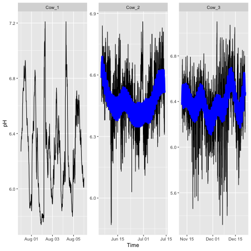

```r
ggplot(data_out, aes(x=Time)) +
    geom_line(mapping=aes(y=pH)) +
    geom_line(mapping=aes(y=prediction), col='blue', lwd=2) +
    facet_wrap(~ID, scale='free')
```

Or daily mean absolute residuals can be calculated e.g.:

```r
daily <- data_out %>% group_by(ID, Date) %>%
    summarise(mean_abs_resid = mean(abs(residual)))
head(daily)
```

```
## # A tibble: 6 x 3
## # Groups:   ID [1]
##   ID    Date       mean_abs_resid
##   <chr> <date>              <dbl>
## 1 Cow_1 2018-07-31             NA
## 2 Cow_1 2018-08-01             NA
## 3 Cow_1 2018-08-02             NA
## 4 Cow_1 2018-08-03             NA
## 5 Cow_1 2018-08-04             NA
## 6 Cow_1 2018-08-05             NA
```

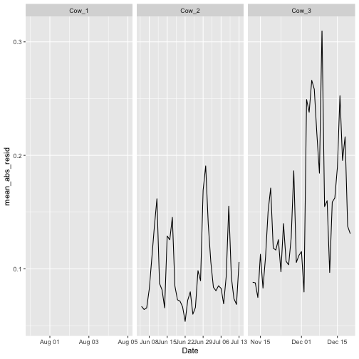

```r
ggplot(daily, aes(x=Date, y=mean_abs_resid)) +
    geom_line() +
    facet_wrap(~ID, scales='free_x')
```

```r
data_ind <- model$ExtractData(ID='Cow_2')
str(data_ind)
```

```
## 'data.frame':    10225 obs. of  6 variables:
##  $ ID        : chr  "Cow_1" "Cow_1" "Cow_1" "Cow_1" ...
##  $ Date      : Date, format: "2018-07-31" "2018-07-31" ...
##  $ Time      : POSIXct, format: "2018-07-31 00:02:00" "2018-07-31 00:12:00" ...
##  $ pH        : num  6.27 6.31 6.33 6.35 6.35 6.36 6.36 6.38 6.38 6.38 ...
##  $ prediction: num  NA NA NA NA NA NA NA NA NA NA ...
##  $ residual  : num  NA NA NA NA NA NA NA NA NA NA ...
```

```r
summary(data_ind)
```

```
##       ID                 Date                 Time
##  Length:10225       Min.   :2015-06-05   Min.   :2015-06-05 00:10:50
##  Class :character   1st Qu.:2015-07-01   1st Qu.:2015-07-01 15:10:50
##  Mode  :character   Median :2019-11-15   Median :2019-11-15 12:04:00
##                     Mean   :2018-03-06   Mean   :2018-03-06 22:18:28
##                     3rd Qu.:2019-12-03   3rd Qu.:2019-12-03 06:01:00
##                     Max.   :2019-12-20   Max.   :2019-12-20 23:59:00
##
##        pH          prediction       residual
##  Min.   :5.320   Min.   :6.111   Min.   :-1.0391
##  1st Qu.:6.290   1st Qu.:6.355   1st Qu.:-0.0945
##  Median :6.420   Median :6.429   Median : 0.0009
##  Mean   :6.409   Mean   :6.422   Mean   : 0.0000
##  3rd Qu.:6.550   3rd Qu.:6.493   3rd Qu.: 0.0999
##  Max.   :7.210   Max.   :6.694   Max.   : 0.7243
##                  NA's   :864     NA's   :864
```

```r
write.csv(data_ind, file='Cow_2.csv', row.names=FALSE)
```